# Situación Problema

Camila Turner Escalante, A01423579 Ramona Nájera Fuentes, A01423596 Patricio Álvarez Hernández, A01423897 Asad Casis López, A01424665

25/05/2022

## 0.1 Información inicial

**Empresa:**  
Se dedica a la producción de piezas automotrices a base de Polipropileno  
**Problema:**  
El porcentaje de defectos está por los cielos

**Objetivo:**  
Determinar las variables importantes para el proceso de extrusión de Polipropileno en una máquina de tornillo sencillo para mejorar la producción.  
**Métrica:**  
Porcentaje de producto defectuoso (cociente entre los defectuosos y el total producido)

| Porcentaje actual | Porcentaje máximo |
| --- | --- |
| 40% | 16% |

## 0.2 Máquina de extrusión: Welex

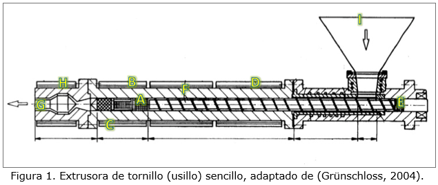

**Información técnica:**  
Hay 9 variables que podrían afectar la calidad del producto (A-I)

| ID | Variable | Unidades |
| --- | --- | --- |
| A | Presión bomba | Bar |
| B | Temperatura plástico 3 (bomba) | °C |
| C | Temperatura plástico 4 (mezcladora) | °C |
| D | Temperatura tornillo (usillo) | °C |
| E | RPM tornillo (usillo) | rpm |
| F | Temperatura barril | °C |
| G | Velocidad extrusión | m/s |
| H | Temperatura enfriadores | °C |
| I | Tipo materia prima | — |
| Y | Porcentaje de defectos | % |

## 0.3 Preparación del entorno y de los datos

```r
#install.packages("readxl")   # Read Excel Files
library(readxl)
#install.packages("dplyr")    # A Grammar of Data Manipulation
library(dplyr)
#install.packages("skimr")    # Compact and Flexible Summaries of Data
library(skimr)
#install.packages("psych")    # Personality/Psychometric/Psychological research
library(psych)
```

```r
#install.packages("GGally")   # Extension to 'ggplot2'
library(GGally)
#install.packages("Hmisc")    # Harrell Miscellaneous
library(Hmisc)
#install.packages("corrplot") # Visualization of a Correlation Matrix
library(corrplot)
#install.packages("lmtest")   # Prueba Durbin-Watson para comprobar independencia de los residuos
library(lmtest)               # También prueba Breusch-Pagan para la homoscedasticidad
#install.packages("nortest")  # Varias pruebas para verificar supuesto de normalidad en los residuos
library(nortest)
```

```r
# Leer info de la producción
datos <- read_excel("./Datos_reto.xlsx", sheet=3, skip=1)
attach(datos)

data <- rename(datos, P_bomba     = A,
       T_plastic3     = B,
       T_plastic4     = C,
       T_tornillo     = D,
       RPM_tornillo   = E,
       T_barril       = F,
       V_extrusión    = G,
       T_enfriadores  = H,
       Tipo_matPrima  = I,
       PCT_defectos   = Y)
```

```r
# Revisón rápida de los datos
skimr::skim(data)
```

Data summary

| Name | data |
| --- | --- |
| Number of rows | 100 |
| Number of columns | 10 |
| _______________________ |  |
| Column type frequency: |  |
| numeric | 10 |
| ________________________ |  |
| Group variables | None |

**Variable type: numeric**

| skim_variable | n_missing | complete_rate | mean | sd | p0 | p25 | p50 | p75 | p100 | hist |
| --- | --- | --- | --- | --- | --- | --- | --- | --- | --- | --- |
| P_bomba | 0 | 1 | 36.98 | 23.22 | 16.00 | 20.00 | 22.00 | 67.00 | 75.00 | ▇▁▁▁▃ |
| T_plastic3 | 0 | 1 | 221.66 | 21.12 | 167.00 | 205.00 | 226.50 | 237.00 | 256.00 | ▁▃▃▇▅ |
| T_plastic4 | 0 | 1 | 214.53 | 20.12 | 184.00 | 199.00 | 207.00 | 235.00 | 252.00 | ▅▇▂▅▃ |
| T_tornillo | 0 | 1 | 220.34 | 22.72 | 186.00 | 200.75 | 212.50 | 243.00 | 264.00 | ▇▇▃▇▃ |
| RPM_tornillo | 0 | 1 | 98.51 | 19.42 | 74.00 | 81.00 | 87.50 | 118.00 | 129.00 | ▇▂▁▃▃ |
| T_barril | 0 | 1 | 146.66 | 28.34 | 108.00 | 120.00 | 144.50 | 175.00 | 189.00 | ▇▂▂▂▇ |
| V_extrusión | 0 | 1 | 1.98 | 1.45 | 0.24 | 0.70 | 1.64 | 2.79 | 5.61 | ▇▅▃▂▂ |
| T_enfriadores | 0 | 1 | 85.29 | 22.36 | 45.00 | 67.00 | 84.00 | 105.00 | 125.00 | ▆▇▇▆▆ |
| Tipo_matPrima | 0 | 1 | 2.04 | 0.94 | 1.00 | 1.00 | 2.00 | 3.00 | 3.00 | ▇▁▂▁▇ |
| PCT_defectos | 0 | 1 | 42.29 | 12.51 | 15.71 | 34.22 | 41.65 | 49.34 | 72.46 | ▃▅▇▃▂ |

## 0.4 Exploración inicial de los datos

Para ver la relación entre ellos e identificar cuáles son los más apropiados para usar en nuestra regresión

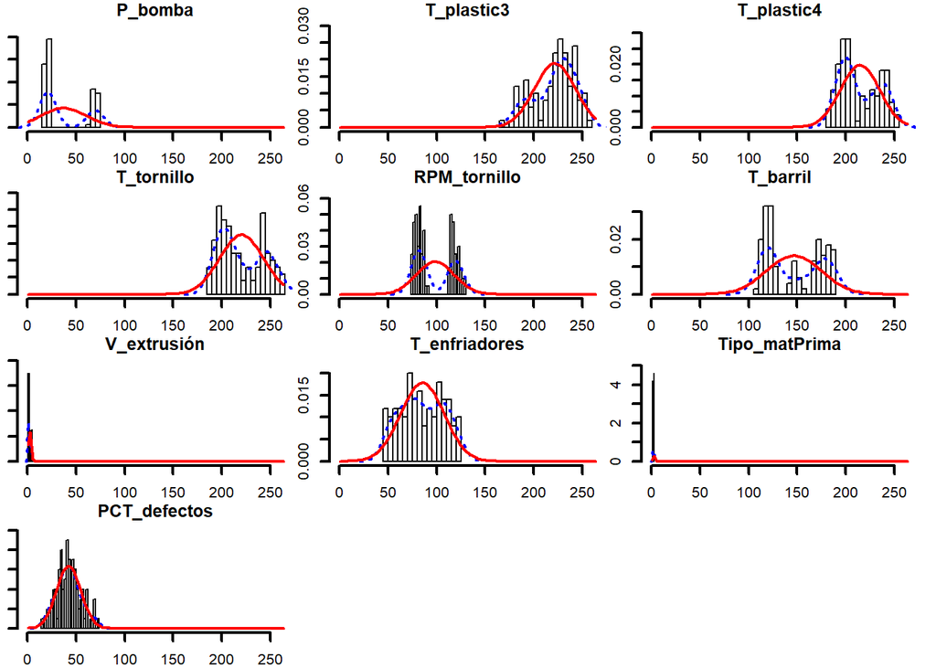

```r
#pairs(datos, pch=20) # Para ir buscando relaciones entre las variables

# 1.CHECAR LA DISTRIBUCIÓN NORMAL mediante histogramas
multi.hist(x=data, dcol=c("blue", "red"), dlty=c("dotted", "solid"), lwd=c(2, 1), main=c("P_bomba", "T_plastic3", "T_plastic4", "T_tornillo", "RPM_tornillo", "T_barril", "V_extrusión", "T_enfriadores", "Tipo_matPrima", "PCT_defectos"))
```

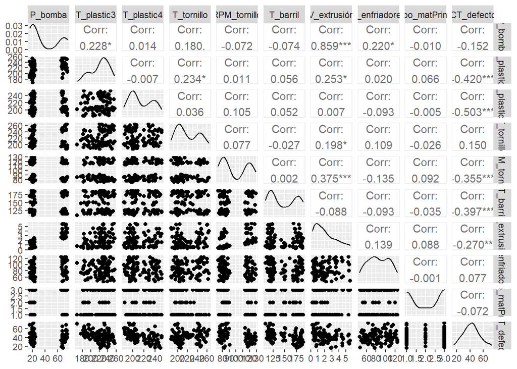

```r
# 2.IDENTIFICAR VARIABLES CON CORRELACIÓN ALTA, pues podrían representar un problema
ggpairs(data)
```

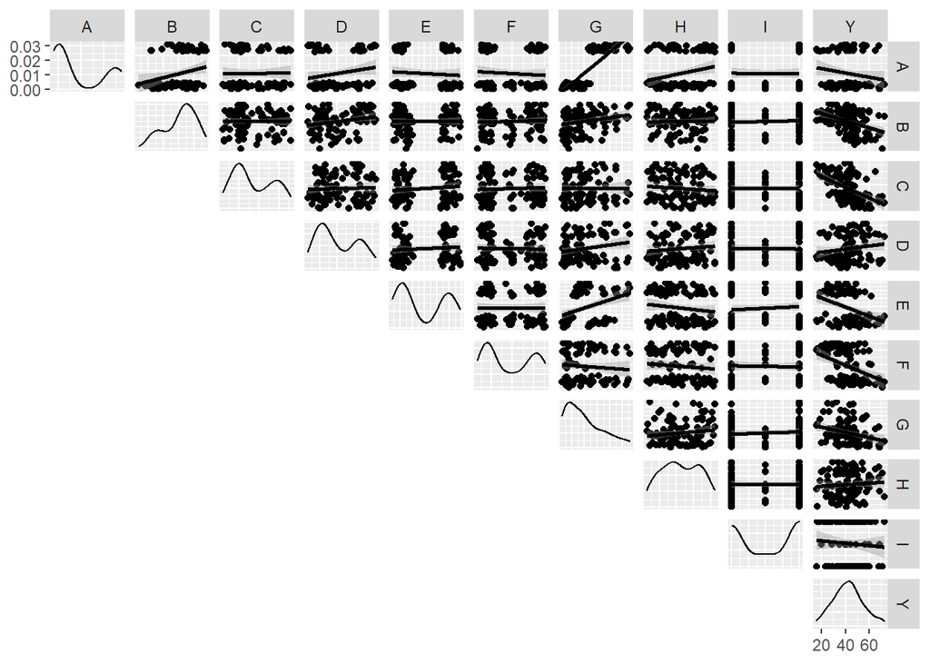

```r
ggpairs(datos, upper=list(continuous="smooth"), lower=list(continuous="blank"), diag=list(continuous="densityDiag"))
```

```r
rcorr(as.matrix(datos))
```

```
##       A     B     C     D     E     F     G     H     I     Y
## A  1.00  0.23  0.01  0.18 -0.07 -0.07  0.86  0.22 -0.01 -0.15
## B  0.23  1.00 -0.01  0.23  0.01  0.06  0.25  0.02  0.07 -0.42
## C  0.01 -0.01  1.00  0.04  0.11  0.05  0.01 -0.09  0.00 -0.50
## D  0.18  0.23  0.04  1.00  0.08 -0.03  0.20  0.11 -0.03  0.15
## E -0.07  0.01  0.11  0.08  1.00  0.00  0.38 -0.13  0.09 -0.36
## F -0.07  0.06  0.05 -0.03  0.00  1.00 -0.09 -0.09 -0.03 -0.40
## G  0.86  0.25  0.01  0.20  0.38 -0.09  1.00  0.14  0.09 -0.27
## H  0.22  0.02 -0.09  0.11 -0.13 -0.09  0.14  1.00  0.00  0.08
## I -0.01  0.07  0.00 -0.03  0.09 -0.03  0.09  0.00  1.00 -0.07
## Y -0.15 -0.42 -0.50  0.15 -0.36 -0.40 -0.27  0.08 -0.07  1.00
##
## n= 100
##
##
## P
##   A      B      C      D      E      F      G      H      I      Y
## A        0.0222 0.8879 0.0734 0.4750 0.4655 0.0000 0.0276 0.9240 0.1314
## B 0.0222        0.9435 0.0194 0.9118 0.5825 0.0113 0.8416 0.5162 0.0000
## C 0.8879 0.9435        0.7195 0.2966 0.6081 0.9423 0.3574 0.9617 0.0000
## D 0.0734 0.0194 0.7195        0.4455 0.7897 0.0482 0.2817 0.8000 0.1368
## E 0.4750 0.9118 0.2966 0.4455        0.9839 0.0001 0.1810 0.3616 0.0003
## F 0.4655 0.5825 0.6081 0.7897 0.9839        0.3863 0.3550 0.7320 0.0000
## G 0.0000 0.0113 0.9423 0.0482 0.0001 0.3863        0.1673 0.3836 0.0067
## H 0.0276 0.8416 0.3574 0.2817 0.1810 0.3550 0.1673        0.9956 0.4491
## I 0.9240 0.5162 0.9617 0.8000 0.3616 0.7320 0.3836 0.9956        0.4769
## Y 0.1314 0.0000 0.0000 0.1368 0.0003 0.0000 0.0067 0.4491 0.4769
```

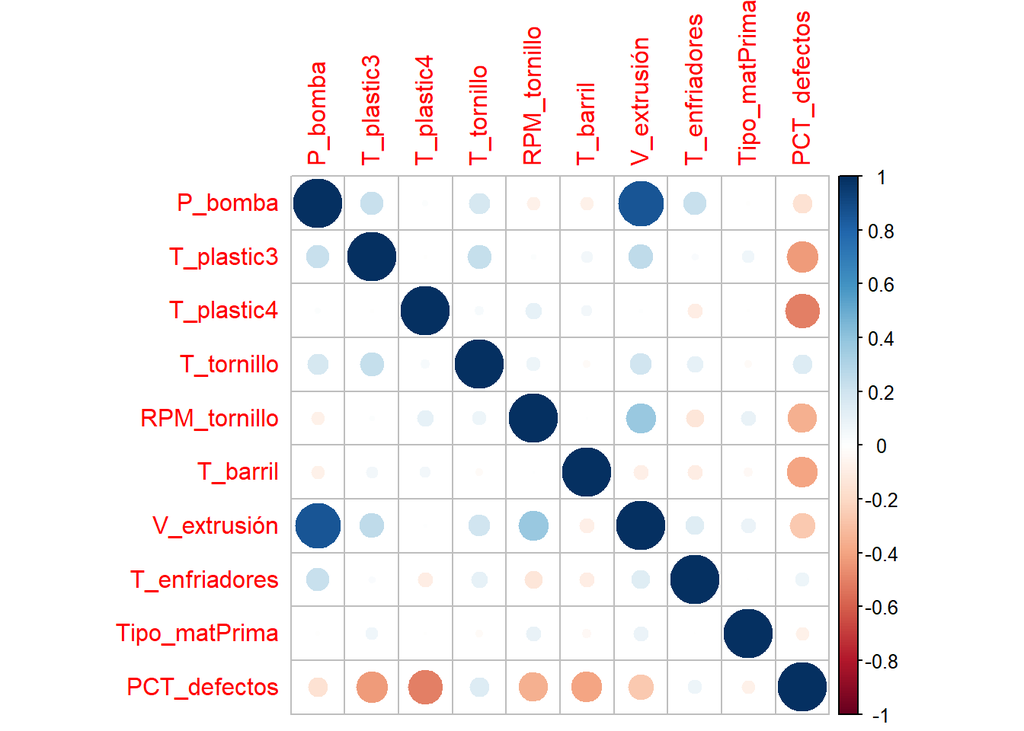

```r
corrplot(cor(data)) # Correlograma
```

## 0.5 Modelo de regresión lineal múltiple

```r
modeloRM <- lm(Y~A+B+C+D+E+F+G+H+I)
summary(modeloRM)
```

```
##
## Call:
## lm(formula = Y ~ A + B + C + D + E + F + G + H + I)
##
## Residuals:
##      Min       1Q   Median       3Q      Max
## -14.2944  -5.1393   0.4251   4.4140  14.9215
##
## Coefficients:
##              Estimate Std. Error t value Pr(>|t|)
## (Intercept) 177.43072   13.41935  13.222  < 2e-16 ***
## A            -0.14673    0.10517  -1.395  0.16642
## B            -0.26388    0.03352  -7.873 7.45e-12 ***
## C            -0.28499    0.03388  -8.413 5.72e-13 ***
## D             0.17386    0.03050   5.701 1.50e-07 ***
## E            -0.25951    0.06933  -3.743  0.00032 ***
## F            -0.15490    0.02366  -6.546 3.54e-09 ***
## G             1.25567    1.82672   0.687  0.49360
## H            -0.02172    0.03088  -0.703  0.48363
## I            -0.36315    0.72289  -0.502  0.61664
## ---
## Signif. codes:  0 '***' 0.001 '**' 0.01 '*' 0.05 '.' 0.1 ' ' 1
##
## Residual standard error: 6.576 on 90 degrees of freedom
## Multiple R-squared:  0.7489, Adjusted R-squared:  0.7237
## F-statistic: 29.82 on 9 and 90 DF,  p-value: < 2.2e-16
```

```r
anova(modeloRM)
```

```
## Analysis of Variance Table
##
## Response: Y
##           Df Sum Sq Mean Sq F value    Pr(>F)
## A          1  357.6   357.6  8.2698  0.005031 **
## B          1 2433.2  2433.2 56.2705 4.292e-11 ***
## C          1 3961.3  3961.3 91.6114 2.224e-15 ***
## D          1 1251.2  1251.2 28.9369 5.869e-07 ***
## E          1 1676.8  1676.8 38.7776 1.486e-08 ***
## F          1 1875.7  1875.7 43.3777 2.954e-09 ***
## G          1   15.8    15.8  0.3648  0.547352
## H          1   21.9    21.9  0.5074  0.478095
## I          1   10.9    10.9  0.2524  0.616644
## Residuals 90 3891.6    43.2
## ---
## Signif. codes:  0 '***' 0.001 '**' 0.01 '*' 0.05 '.' 0.1 ' ' 1
```

Si quitamos las variables velocidad extrusión (G), temperatura enfriadores (H) y tipo materia prima (I) que en el modelo pasado tenían un valor p mayor a alfa (0.05), esto es lo que queda

```r
modeloRM2 <- lm(Y~A+B+C+D+E+F)
summary(modeloRM2)
```

```
##
## Call:
## lm(formula = Y ~ A + B + C + D + E + F)
##
## Residuals:
##      Min       1Q   Median       3Q      Max
## -14.3359  -5.5536   0.0095   4.3718  15.1781
##
## Coefficients:
##              Estimate Std. Error t value Pr(>|t|)
## (Intercept) 170.65959   11.47582  14.871  < 2e-16 ***
## A            -0.08159    0.02943  -2.772  0.00672 **
## B            -0.26003    0.03259  -7.979 3.75e-12 ***
## C            -0.28736    0.03277  -8.770 8.18e-14 ***
## D             0.17226    0.03002   5.738 1.19e-07 ***
## E            -0.21654    0.03411  -6.348 7.87e-09 ***
## F            -0.15475    0.02326  -6.654 1.95e-09 ***
## ---
## Signif. codes:  0 '***' 0.001 '**' 0.01 '*' 0.05 '.' 0.1 ' ' 1
##
## Residual standard error: 6.509 on 93 degrees of freedom
## Multiple R-squared:  0.7457, Adjusted R-squared:  0.7293
## F-statistic: 45.46 on 6 and 93 DF,  p-value: < 2.2e-16
```

```r
anova(modeloRM2)
```

```
## Analysis of Variance Table
##
## Response: Y
##           Df Sum Sq Mean Sq F value    Pr(>F)
## A          1  357.6   357.6  8.4399  0.004586 **
## B          1 2433.2  2433.2 57.4286 2.553e-11 ***
## C          1 3961.3  3961.3 93.4968 1.024e-15 ***
## D          1 1251.2  1251.2 29.5324 4.394e-07 ***
## E          1 1676.8  1676.8 39.5756 1.020e-08 ***
## F          1 1875.7  1875.7 44.2704 1.951e-09 ***
## Residuals 93 3940.3    42.4
## ---
## Signif. codes:  0 '***' 0.001 '**' 0.01 '*' 0.05 '.' 0.1 ' ' 1
```

Después de hacer este segundo modelo observamos que R^2 ajustada casi no cambió y sigue siendo un valor aceptable. En cuanto a los valores p de las variables, todos están por debajo del valor alfa (0.05).  
Ahora vamos a usar la función *step()* para obtener el mejor modelo de regresión lineal múltiple.

```r
step(modeloRM)
```

```
## Start:  AIC=386.14
## Y ~ A + B + C + D + E + F + G + H + I
##
##        Df Sum of Sq    RSS    AIC
## - I     1     10.91 3902.5 384.42
## - G     1     20.43 3912.1 384.66
## - H     1     21.39 3913.0 384.69
## <none>              3891.6 386.14
## - A     1     84.16 3975.8 386.28
## - E     1    605.77 4497.4 398.61
## - D     1   1405.17 5296.8 414.97
## - F     1   1852.90 5744.5 423.08
## - B     1   2680.04 6571.7 436.54
## - C     1   3060.26 6951.9 442.16
##
## Step:  AIC=384.42
## Y ~ A + B + C + D + E + F + G + H
##
##        Df Sum of Sq    RSS    AIC
## - G     1     15.45 3918.0 382.82
## - H     1     21.94 3924.5 382.98
## - A     1     75.50 3978.0 384.34
## <none>              3902.5 384.42
## - E     1    594.87 4497.4 396.61
## - D     1   1420.11 5322.6 413.46
## - F     1   1847.62 5750.2 421.18
## - B     1   2699.57 6602.1 435.00
## - C     1   3074.67 6977.2 440.52
##
## Step:  AIC=382.82
## Y ~ A + B + C + D + E + F + H
##
##        Df Sum of Sq    RSS    AIC
## - H     1      22.3 3940.3 381.38
## <none>              3918.0 382.82
## - A     1     281.0 4199.0 387.74
## - D     1    1415.7 5333.7 411.66
## - E     1    1729.7 5647.7 417.38
## - F     1    1895.3 5813.3 420.27
## - B     1    2713.3 6631.3 433.44
## - C     1    3280.6 7198.6 441.65
##
## Step:  AIC=381.38
## Y ~ A + B + C + D + E + F
##
##        Df Sum of Sq    RSS    AIC
## <none>              3940.3 381.38
## - A     1     325.7 4265.9 387.32
## - D     1    1395.0 5335.2 409.69
## - E     1    1707.5 5647.8 415.38
## - F     1    1875.7 5815.9 418.32
## - B     1    2697.3 6637.6 431.53
## - C     1    3258.4 7198.7 439.65
```

```
##
## Call:
## lm(formula = Y ~ A + B + C + D + E + F)
##
## Coefficients:
## (Intercept)            A            B            C            D            E
##   170.65959     -0.08159     -0.26003     -0.28736      0.17226     -0.21654
##           F
##    -0.15475
```

De acuerdo con la función *step()*, el mejor modelo es utilizando las variables A,B,C,D,E y F y se rechaza la hiótesis nula, por lo que también conservamos el valor del intercepto. La R^2 ajustada tiene un valor de 0.7293.

Ahora hacemos la validación de los residuos con sus gráficas.

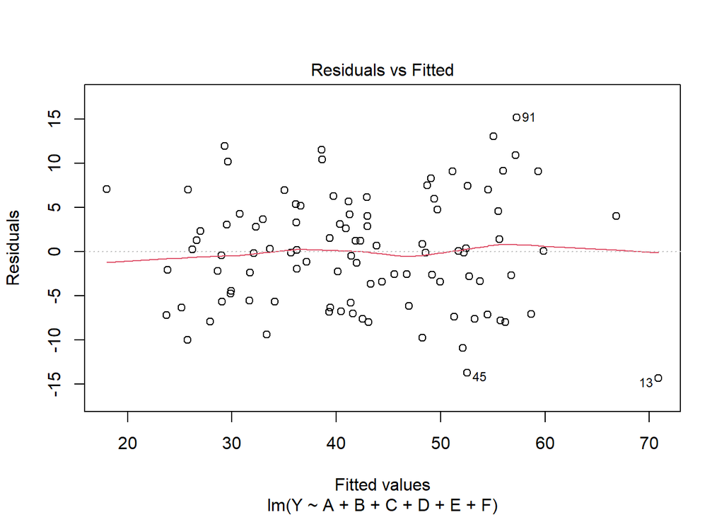

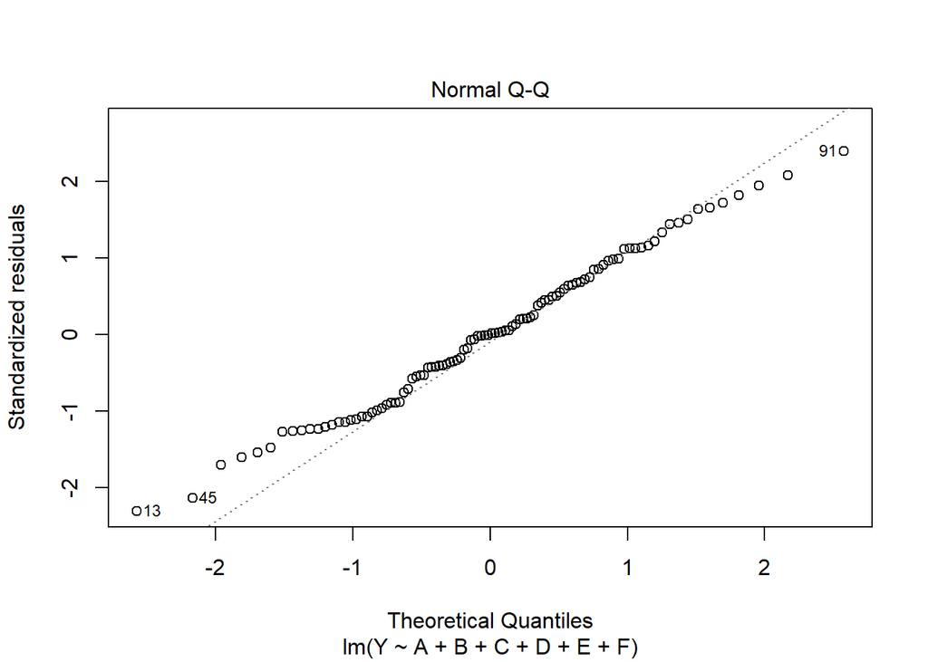

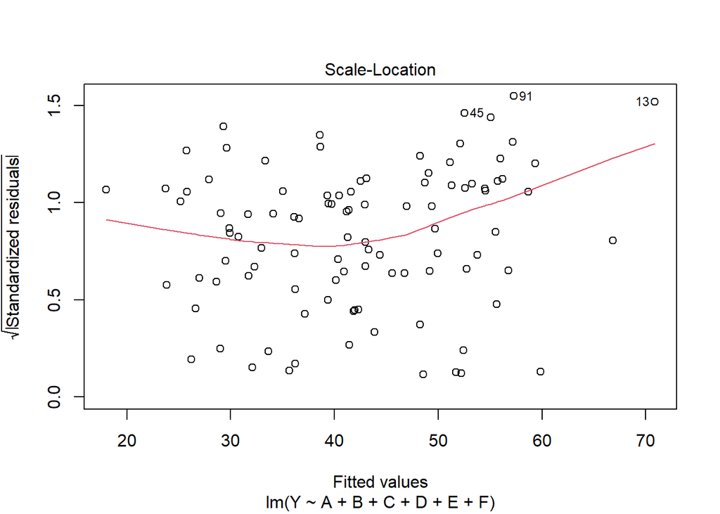

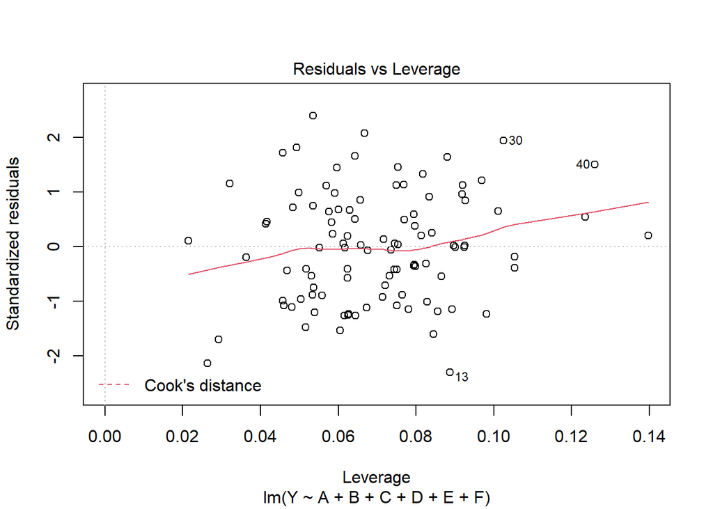

```r
plot(modeloRM2)
```

Hacemos otras pruebas para validar los residuos. En estas pruebas el valor p tiene que ser mayor a alfa (0.05).

```r
# Prueba Durbin-Watson (independencia de los residuos)
dwtest(modeloRM2, data = y)
```

```
##
##  Durbin-Watson test
##
## data:  modeloRM2
## DW = 2.233, p-value = 0.8844
## alternative hypothesis: true autocorrelation is greater than 0
```

```r
# Prueba Breusch-Pagan para la homoscedasticidad
bptest(modeloRM2)
```

```
##
##  studentized Breusch-Pagan test
##
## data:  modeloRM2
## BP = 8.9278, df = 6, p-value = 0.1777
```

```r
# Para revisar la normalidad de los residuos
lillie.test(modeloRM2$residuals)
```

```
##
##  Lilliefors (Kolmogorov-Smirnov) normality test
##
## data:  modeloRM2$residuals
## D = 0.069563, p-value = 0.2745
```

Afortunadamente, todas las pruebas cumplieron con el requisito de tener un valor p mayor a alfa (0.05).